# Predicting Barbell Lifts from Accelerometer Data

qtrn0707

July 24, 2017

## Load, Clean and Split the Data

### Load the Data

```r
validation <- read.csv("pml-testing.csv"); building <- read.csv("pml-training.csv")
```

### Clean the Data

Some rows of the *building* dataset contains summary statistics for the preceding rows (*new_window* == *yes*). These rows are excluded from the analysis. The columns containing summary statistics (those with names that start with *kurtosis*, *skewness*, *max*, *min*, *amplitude*, *var*, *avg*, *stddev*) are also excluded.

```r
building <- building[building$new_window != "yes",]
validation <- validation[validation$new_window != "yes",]

removable <- function(name) {
        prefixes <- c("kurtosis", "skewness", "max", "min", "amplitude", "var", "avg", "stddev")
        any(startsWith(name, prefixes))
}

removableIndices <- sapply(names(building), removable)
building <- building[,!removableIndices]; validation <- validation[,!removableIndices]
```

There are some variables that are irrelevant to the analysis:

- *X* (column index = 1): the row index
- *user_name* (column index = 2): name of the person which the observation was generated from
- *raw_timestamp_part_1*, *raw_timestamp_part_2*, *ctvd_timestamp* (column index = 3, 4, 5): the time stamps
- *new_window* (column index = 6): indicates whether the row is a summary row or not
- *num_window* (column index = 7): the numerical index of the time window when the data was generated.

These variables are also excluded:

```r
building <- building[,-(1:7)]
validation <- validation[,-(1:7)]
```

### Create the Training and Test Sets

```r
library(caret); set.seed(1221)

inTrain <- createDataPartition(building$classe, p=0.7, list=F)
training <- building[inTrain,]; testing <- building[-inTrain,]

dim(training); dim(testing)
```

```
## [1] 13453    53
```

```
## [1] 5763   53
```

### Summarizing the Training Set

```r
table(sapply(training, class))
```

```
##
##  factor integer numeric
##       1      25      27
```

```r
summary(training$classe)
```

```
##    A    B    C    D    E
## 3830 2603 2347 2203 2470
```

## Models

### Notes

This is a classification problem with 5 levels so generalized linear model (method=“glm”) will not be implemented.

The cross-validation scheme is 10-fold cross-validation. Cross-validation is chosen over bootstrapping because it requires less computational time. In a problem with a large sample size like this, 10-fold cross-validation bias will be small.

```r
tenFoldCV <- trainControl(method = "cv", allowParallel = TRUE)
```

### Decision Tree

```r
rpartModel <- train(classe ~ ., data=training, method="rpart", trControl=tenFoldCV)
```

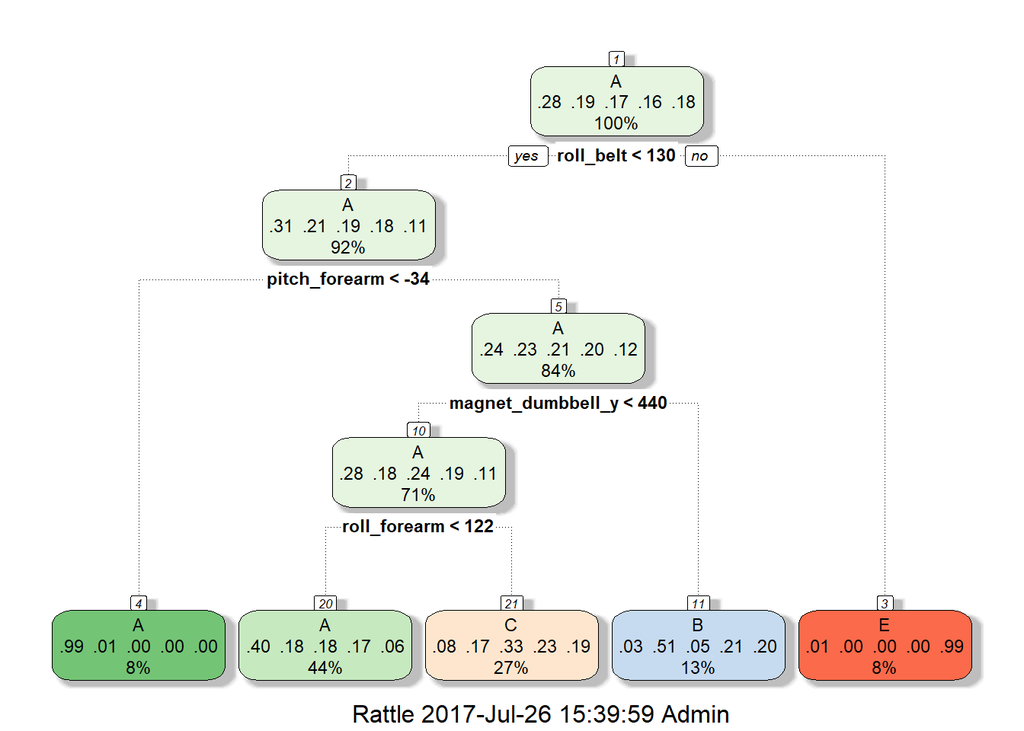

```r
library(rattle)
fancyRpartPlot(rpartModel$finalModel)
```

```r
rpartPredTrain <- predict(rpartModel, training)
confusionMatrix(rpartPredTrain, training$classe)$overall
```

```
##       Accuracy          Kappa  AccuracyLower  AccuracyUpper   AccuracyNull
##      0.4957259      0.3406570      0.4872416      0.5042119      0.2846949
## AccuracyPValue  McnemarPValue
##      0.0000000            NaN
```

### Decision Tree Bagging

```r
treebagModel <- train(classe ~ ., data=training, method="treebag", trControl=tenFoldCV)
```

```r
treebagPredTrain <- predict(treebagModel, training)
treebagModel$results
```

```
##   parameter  Accuracy     Kappa  AccuracySD     KappaSD
## 1      none 0.9853576 0.9814766 0.003704997 0.004686592
```

### Random Forests

```r
rfModel <- train(classe ~ ., data=training, method="rf", ntree=10, trControl=tenFoldCV)
```

```r
rfPredTrain <- predict(rfModel, training)
confusionMatrix(rfPredTrain, training$classe)$overall
```

```
##       Accuracy          Kappa  AccuracyLower  AccuracyUpper   AccuracyNull
##      0.9997770      0.9997179      0.9993484      0.9999540      0.2846949
## AccuracyPValue  McnemarPValue
##      0.0000000            NaN
```

### Gradient Boosting

Because gradient boosting is too computationally expensive, we will not perform it.

### Linear Discriminant Analysis

```r
ldaModel <- train(classe ~ ., data=training, method="lda", trControl=tenFoldCV)
ldaModel$results
```

```
##   parameter  Accuracy     Kappa AccuracySD    KappaSD
## 1      none 0.7036347 0.6249825 0.01716234 0.02163993
```

### Combining Models

Of the 4 models trained above, Decision Tree Bagging and Random Forests have very high in-sample accuracy, far higher than the other two. Here we combine these two models using a multinomial regression (method=“multinom”).

```r
predTrainDF <- data.frame(treebag = treebagPredTrain, rf = rfPredTrain, classe = training$classe)

## Proportion of predictions both methods agree on
mean(predTrainDF$treebag == predTrainDF$rf)
```

```
## [1] 0.999331
```

```r
## Fit a multinom model that combines both predictors
multinomModel <- train(classe ~ ., data=predTrainDF, method="multinom", trace=F, trControl=tenFoldCV)
multinomPredTrain <- predict(multinomModel, predTrainDF)
```

```r
## Compare accuracy of the two individual predictors and the combined predictors on the training set
mean(treebagPredTrain == training$classe)
```

```
## [1] 0.9997027
```

```r
mean(rfPredTrain == training$classe)
```

```
## [1] 0.999777
```

```r
mean(multinomPredTrain == training$classe)
```

```
## [1] 0.9999257
```

## Test the Models on the Test Set

```r
## Decision Tree
rpartPredTest <- predict(rpartModel, testing)
confusionMatrix(rpartPredTest, testing$classe)$overall
```

```
##       Accuracy          Kappa  AccuracyLower  AccuracyUpper   AccuracyNull
##   4.941871e-01   3.393366e-01   4.811978e-01   5.071822e-01   2.847475e-01
## AccuracyPValue  McnemarPValue
##  9.255861e-246            NaN
```

```r
## Decision Tree Bagging
treebagPredTest <- predict(treebagModel, testing)
confusionMatrix(treebagPredTest, testing$classe)$overall
```

```
##       Accuracy          Kappa  AccuracyLower  AccuracyUpper   AccuracyNull
##      0.9868124      0.9833160      0.9835212      0.9895960      0.2847475
## AccuracyPValue  McnemarPValue
##      0.0000000            NaN
```

```r
## Random Forests
rfPredTest <- predict(rfModel, testing)
confusionMatrix(rfPredTest, testing$classe)$overall
```

```
##       Accuracy          Kappa  AccuracyLower  AccuracyUpper   AccuracyNull
##   0.9880270692   0.9848539010   0.9848716234   0.9906727307   0.2847475273
## AccuracyPValue  McnemarPValue
##   0.0000000000   0.0005474985
```

```r
## Linear Discriminant Analysis
ldaPredTest <- predict(ldaModel, testing)
confusionMatrix(ldaPredTest, testing$classe)$overall
```

```
##       Accuracy          Kappa  AccuracyLower  AccuracyUpper   AccuracyNull
##   6.979004e-01   6.180964e-01   6.858608e-01   7.097394e-01   2.847475e-01
## AccuracyPValue  McnemarPValue
##   0.000000e+00   9.032969e-54
```

```r
## Combined Model
predTestDF <- data.frame(treebag = treebagPredTest, rf = rfPredTest, classe = testing$classe)
multinomPredTest <- predict(multinomModel, predTestDF)
confusionMatrix(multinomPredTest, testing$classe)$overall
```

```
##       Accuracy          Kappa  AccuracyLower  AccuracyUpper   AccuracyNull
##      0.9869859      0.9835351      0.9837137      0.9897502      0.2847475
## AccuracyPValue  McnemarPValue
##      0.0000000            NaN
```

The most accurate model among the 5 is random forests. This will be chosen as our final prediction algorithm.

```r
OSE <- as.numeric(1 - confusionMatrix(multinomPredTest, testing$classe)$overall[1])
print(OSE)
```

```
## [1] 0.01301406
```

## Final Model

The final model chosen is random forests built on the building set.

```r
rfModelBuild <- train(classe ~ ., data=building, method="rf", ntree=10, trControl=tenFoldCV)
```

```r
rfPredBuild <- predict(rfModelBuild, building)

ISE <- 1 - mean(rfPredBuild == building$classe); print(ISE)
```

```
## [1] 0
```

The final in-sample error rate is 0%, or 0 false classifications out of 19216.

## Predict the Validation Set

```r
rfPredValidation <- predict(rfModelBuild, validation)
```

Our final predictions are:

```r
print(rfPredValidation)
```

```
##  [1] B A B A A E D B A A B C B A E E A B B B
## Levels: A B C D E
```